# seshat_epoques

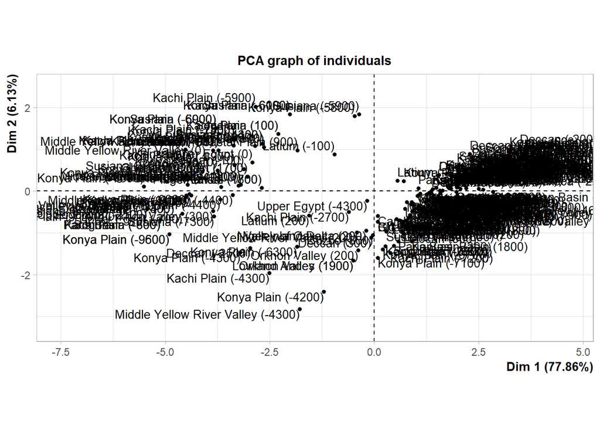

```r
plot(pca3, cex=pca3$ind$cos2, choix="ind")
```

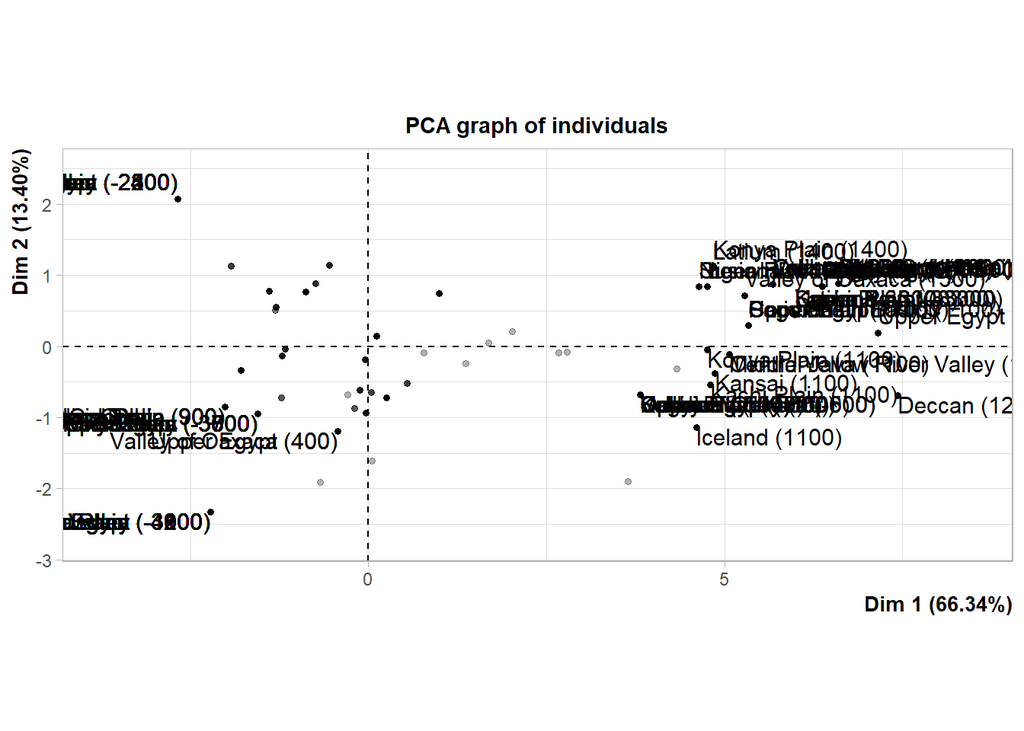

```r
plot(pca1, select="cos2 0.8", choix="ind")
```

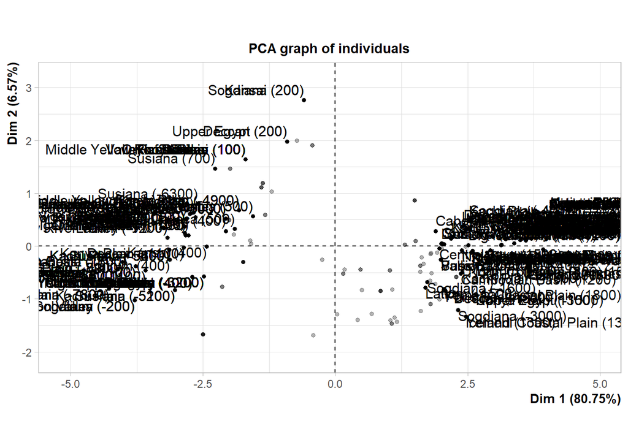

```r
plot(pca2, select="cos2 0.8", choix="ind")
```

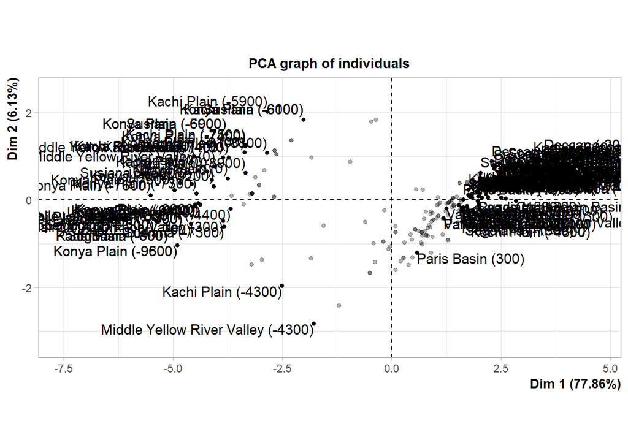

```r
plot(pca3, select="cos2 0.8", choix="ind")
```

### 3.3 k-means et CAH

On a vu sur l’ACP qu’on pouvait distinguer environ deux groupes. On essaie des k-means :

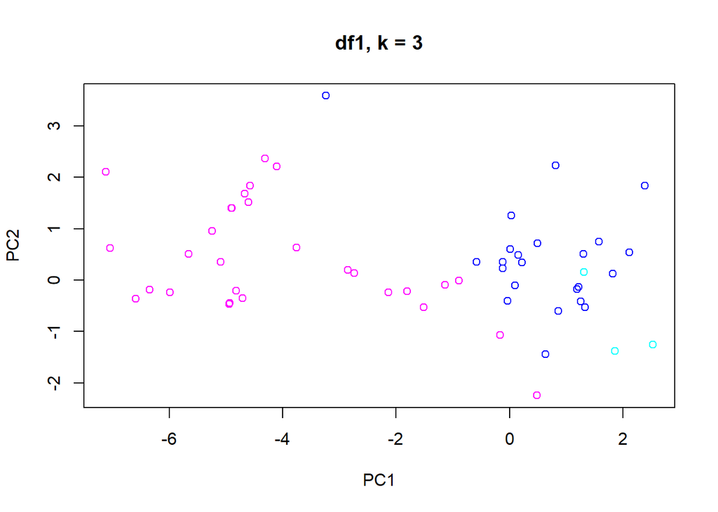

```r
kmeans.result = kmeans(df1,3)
plot(C1[,1:2],type="p",xlab='PC1',ylab='PC2',col = kmeans.result$cluster+3, main="df1, k = 3")
```

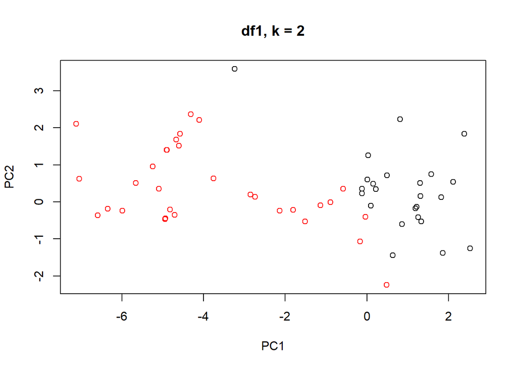

```r
kmeans.result = kmeans(df1,2)
plot(C1[,1:2],type="p",xlab='PC1',ylab='PC2',col = kmeans.result$cluster, main="df1, k = 2")
```

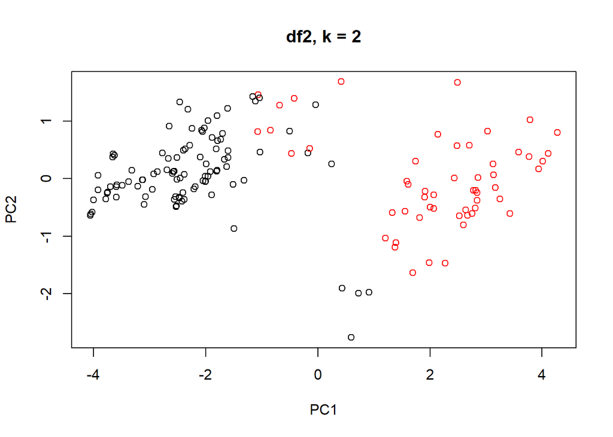

```r
kmeans.result = kmeans(df2,2)
plot(C2[,1:2],type="p",xlab='PC1',ylab='PC2',col = kmeans.result$cluster, main="df2, k = 2")
```

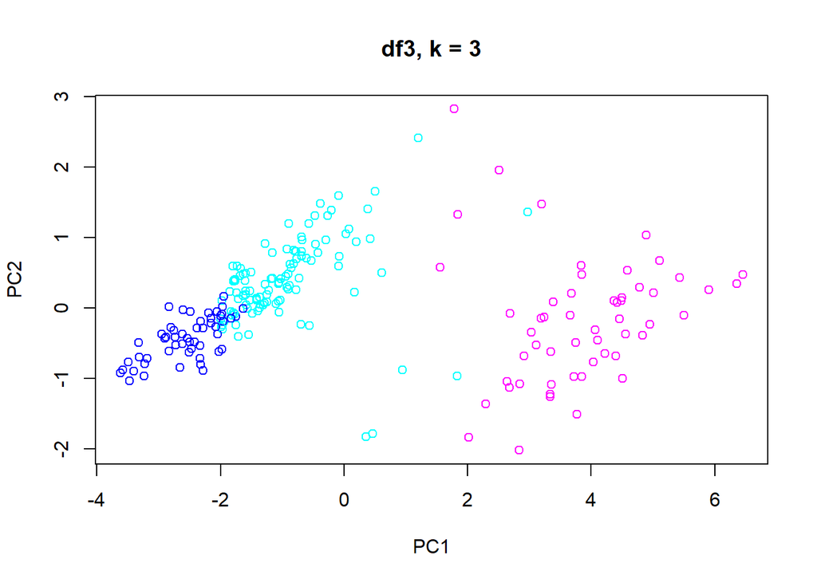

```r
kmeans.result = kmeans(df3,3)
plot(C3[,1:2],type="p",xlab='PC1',ylab='PC2',col = kmeans.result$cluster+3, main="df3, k = 3")
```

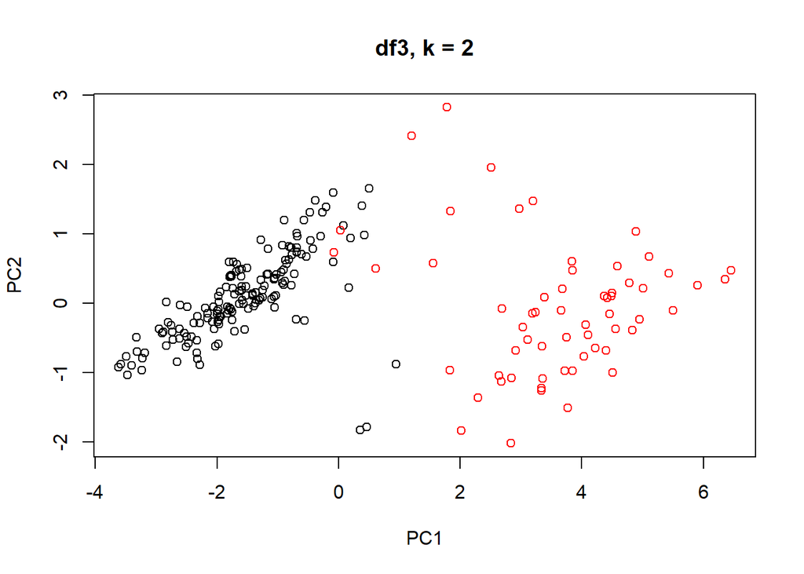

```r
kmeans.result = kmeans(df3,2)
plot(C3[,1:2],type="p",xlab='PC1',ylab='PC2',col = kmeans.result$cluster, main="df3, k = 2")
```

Pour k = 3, on a un groupe qui contient les points dispersés du milieu. Pour savoir quelle classification est la plus pertinente, essayons un CAH :

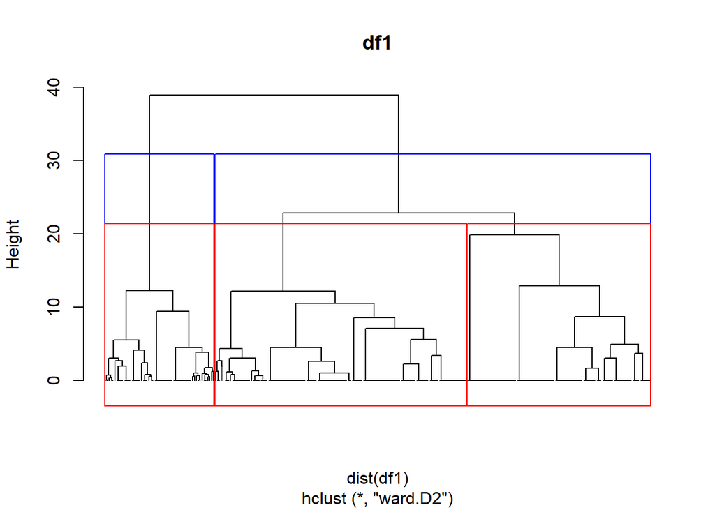

```r
hc1 <- hclust(dist(df1), method="ward.D2")
plot(hc1,hang=-1,labels = FALSE, main="df1")
rect.hclust(hc1,k=2,border = 4)
rect.hclust(hc1,k=3)
```

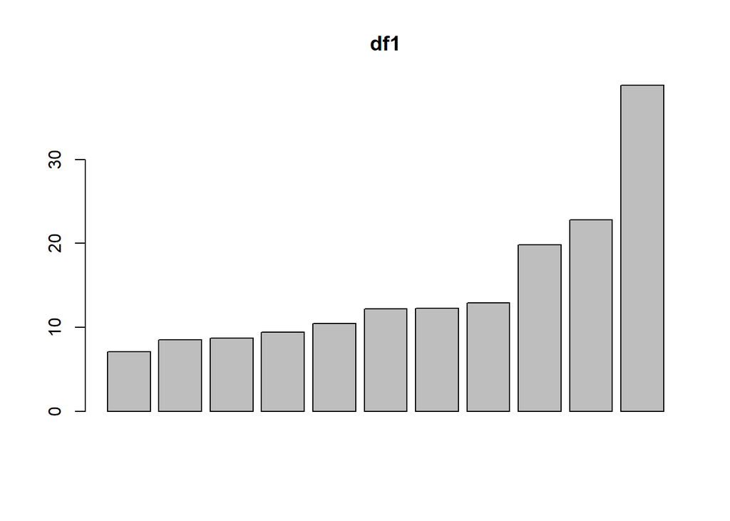

```r
barplot(hc1$height[(length(hc1$height)-10):(length(hc1$height))], main="df1")
```

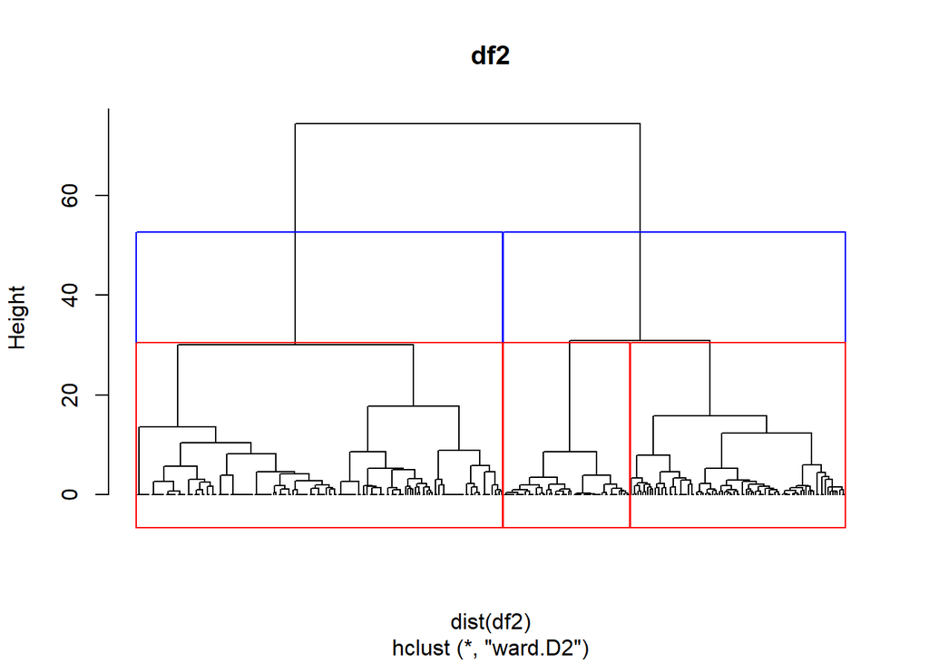

```r
hc2 <- hclust(dist(df2), method="ward.D2")
plot(hc2,hang=-1,labels = FALSE, main="df2")
rect.hclust(hc2,k=2,border = 4)
rect.hclust(hc2,k=3)
```

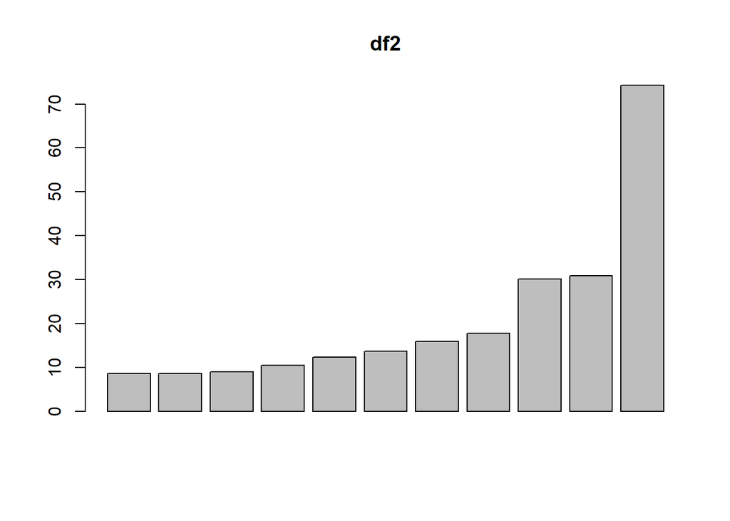

```r
barplot(hc2$height[(length(hc2$height)-10):(length(hc2$height))], main="df2")
```

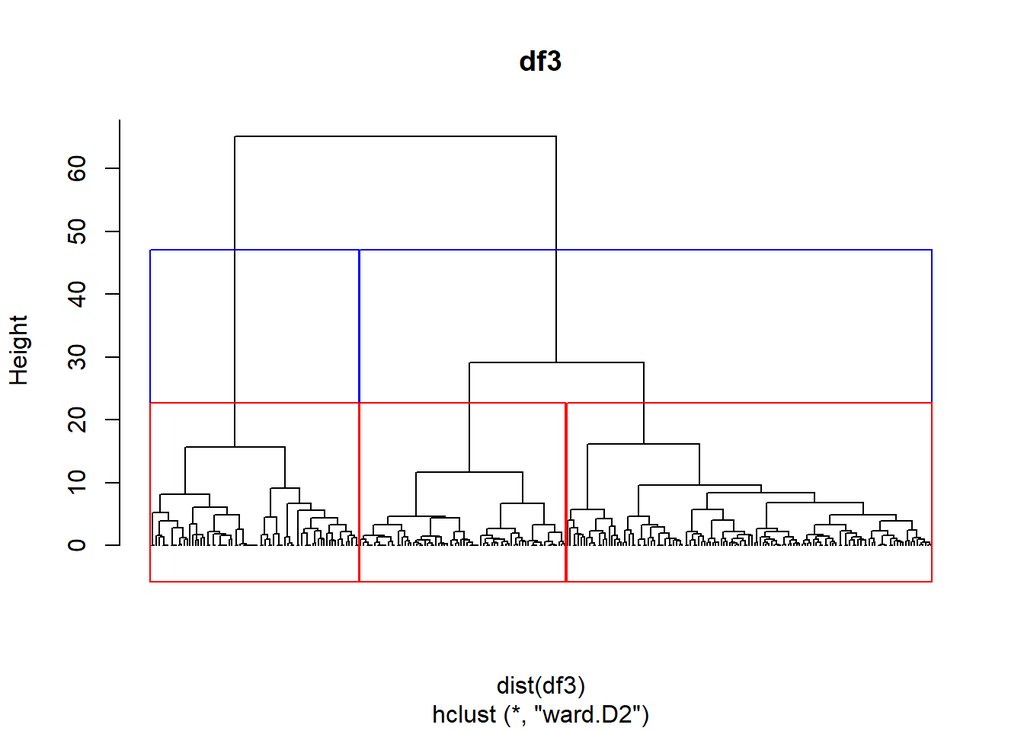

```r
hc3 <- hclust(dist(df3), method="ward.D2")
plot(hc3,hang=-1,labels = FALSE, main="df3")
rect.hclust(hc3,k=2,border = 4)
rect.hclust(hc3,k=3)
```

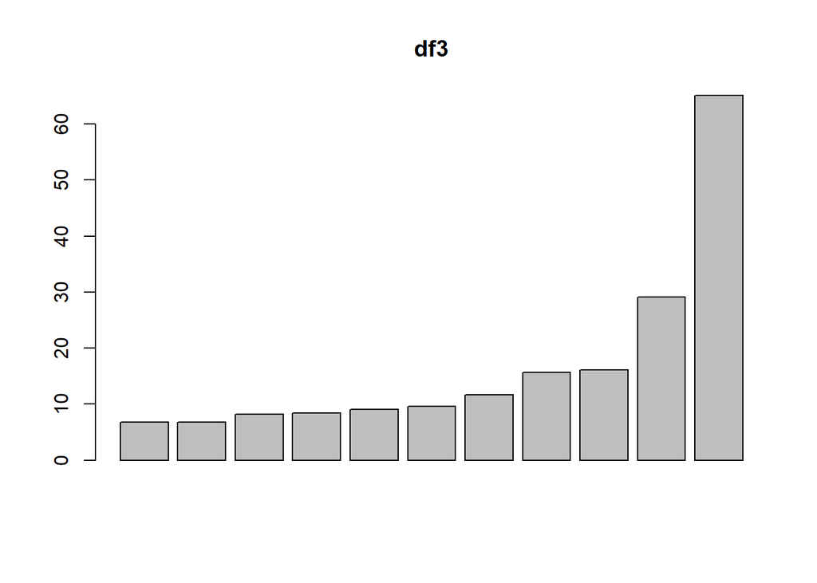

```r
barplot(hc3$height[(length(hc3$height)-10):(length(hc3$height))], main="df3")
```

Il semble qu’il faille garder à chaque fois 2 classes.

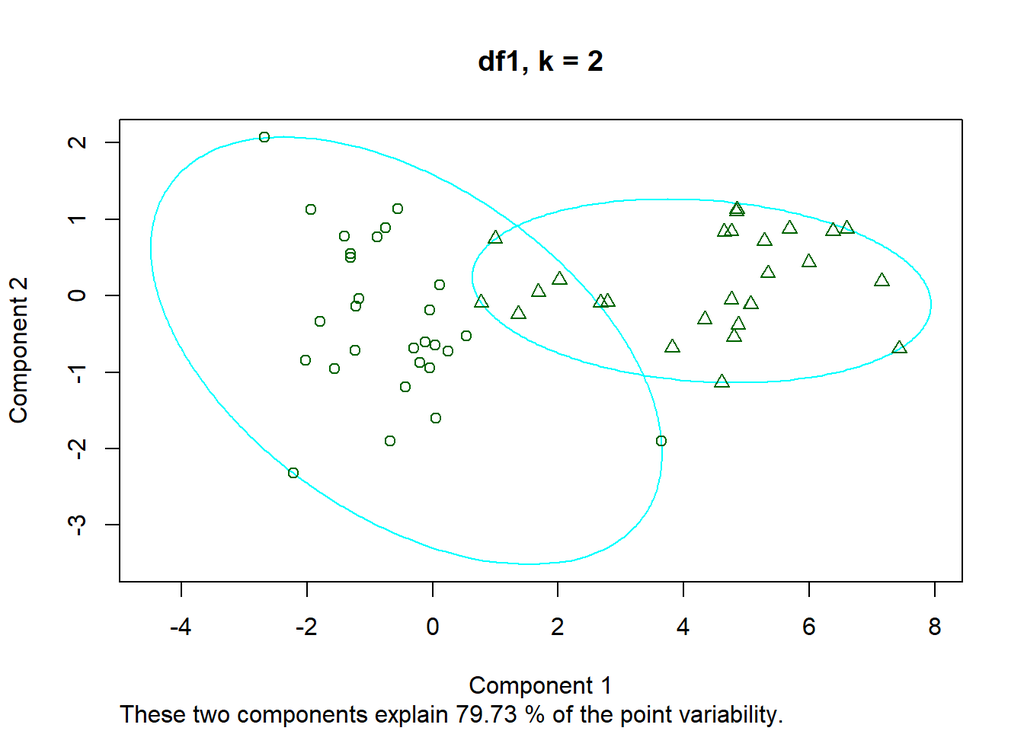

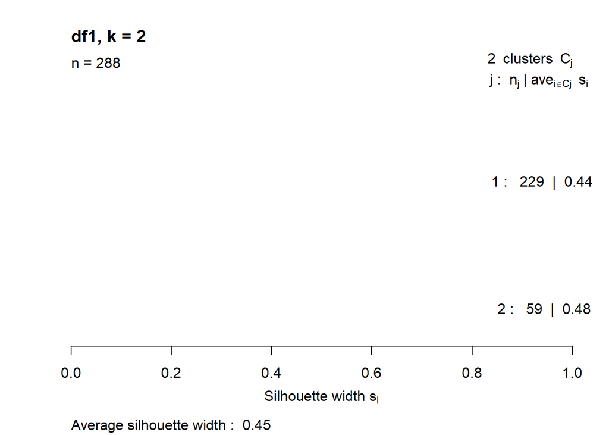

```r
library(cluster)
pam.result <- pam(df1,2)
plot(pam.result, main="df1, k = 2")
```

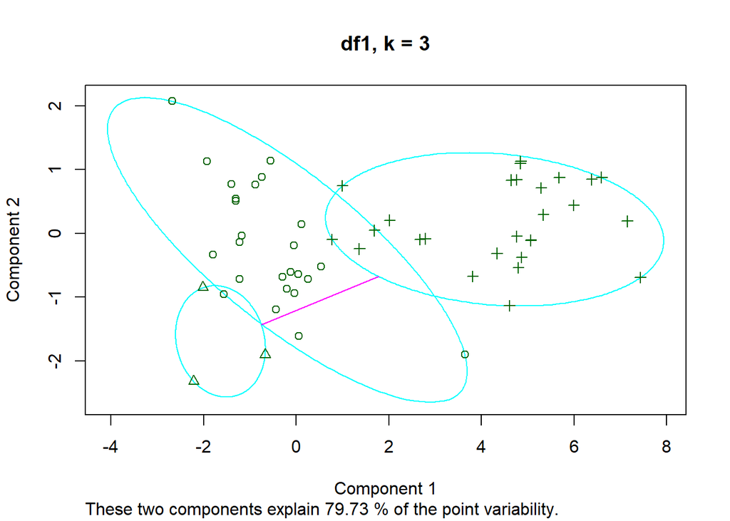

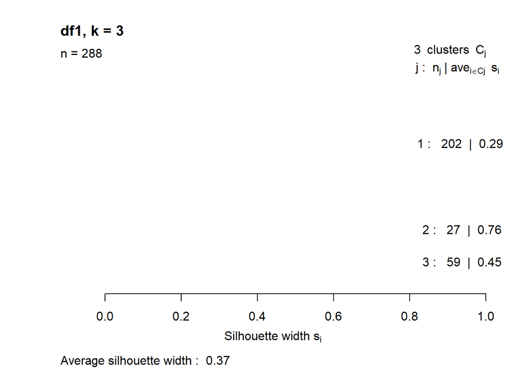

```r
pam.result <- pam(df1,3)
plot(pam.result, main="df1, k = 3")
```

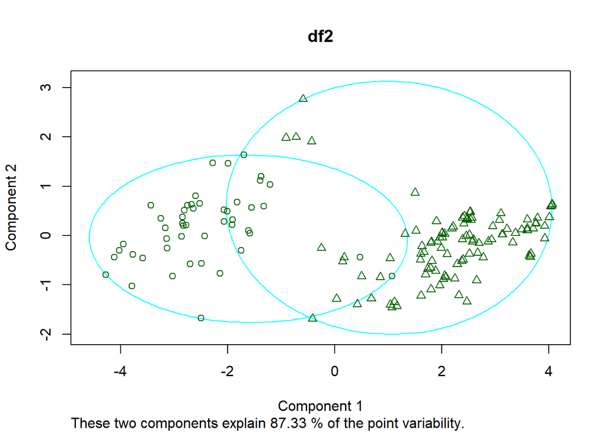

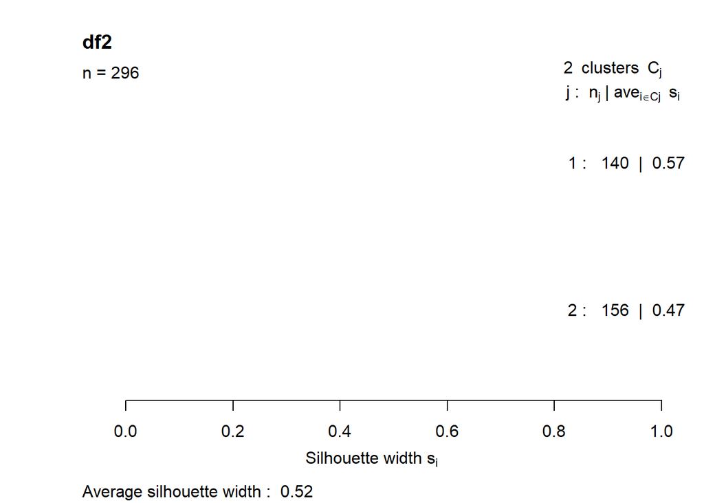

```r
pam.result <- pam(df2,2)
plot(pam.result, main="df2")
```

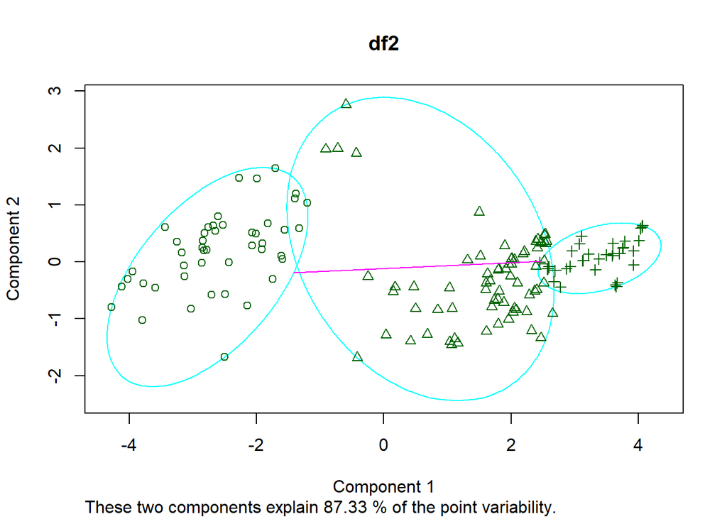

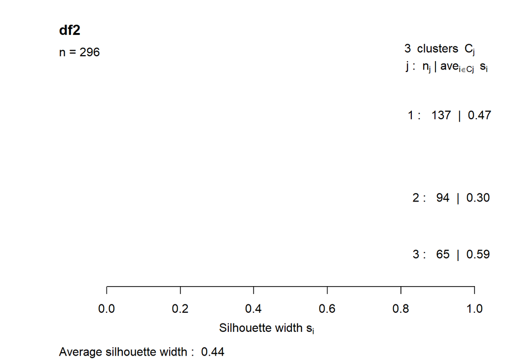

```r
pam.result <- pam(df2,3)
plot(pam.result, main="df2")
```

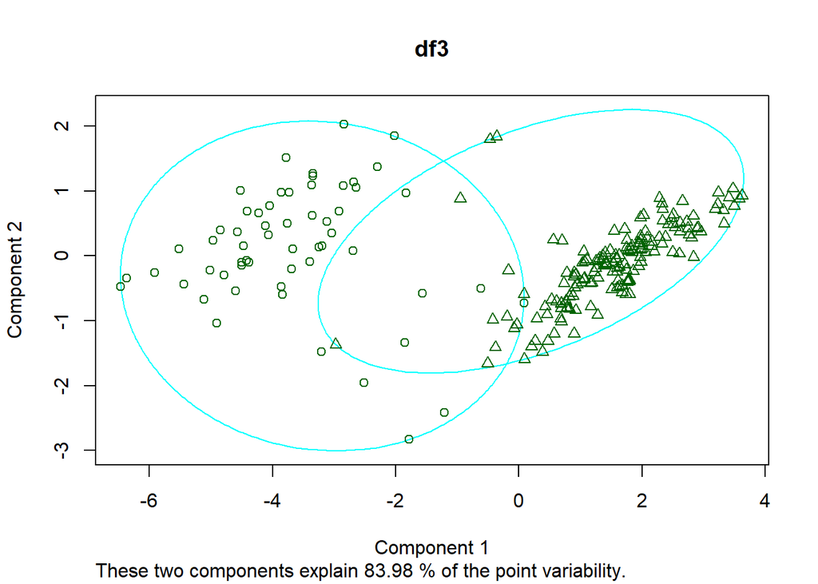

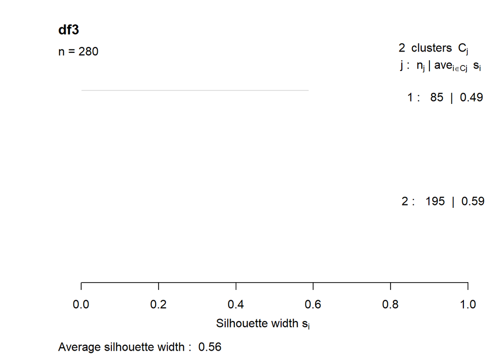

```r
pam.result <- pam(df3,2)
plot(pam.result, main="df3")
```

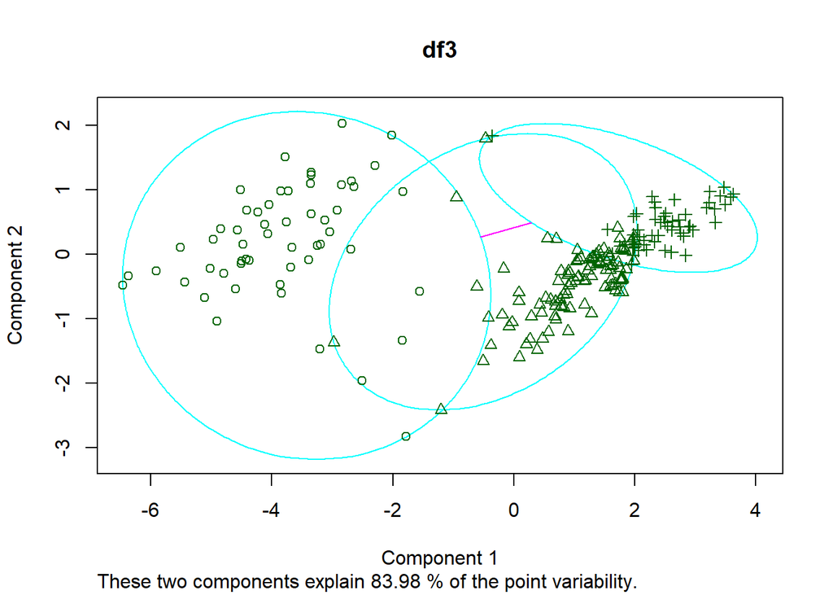

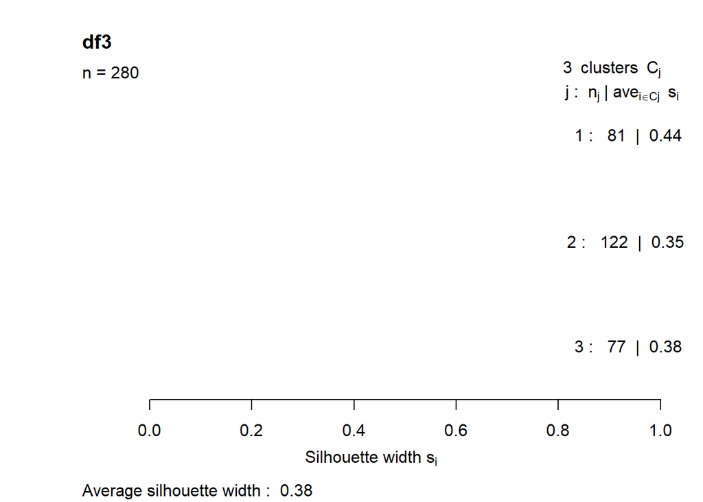

```r
pam.result <- pam(df3,3)
plot(pam.result, main="df3")
```

Je ne sais pas trop ce que tout cela signifie. Peut être du côté de la fonction FAMD ?

Une fois les groupes réunis, il serait intéressant de comprendre ce qui les distingue, les deux dimensions n’y suffisent pas entièrement :

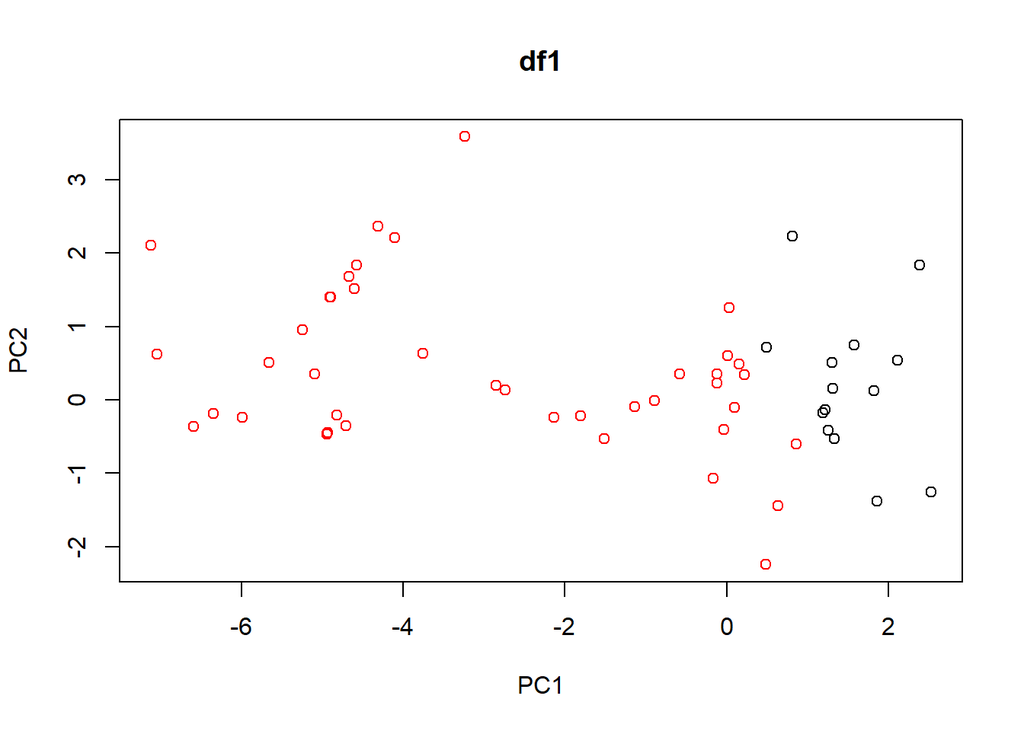

```r
k = 2
kmeans.result = kmeans(df1,2)
plot(C1[,1:2],type="p",xlab='PC1',ylab='PC2',col = kmeans.result$cluster, main = "df1") #affiche kmeans en acp
```

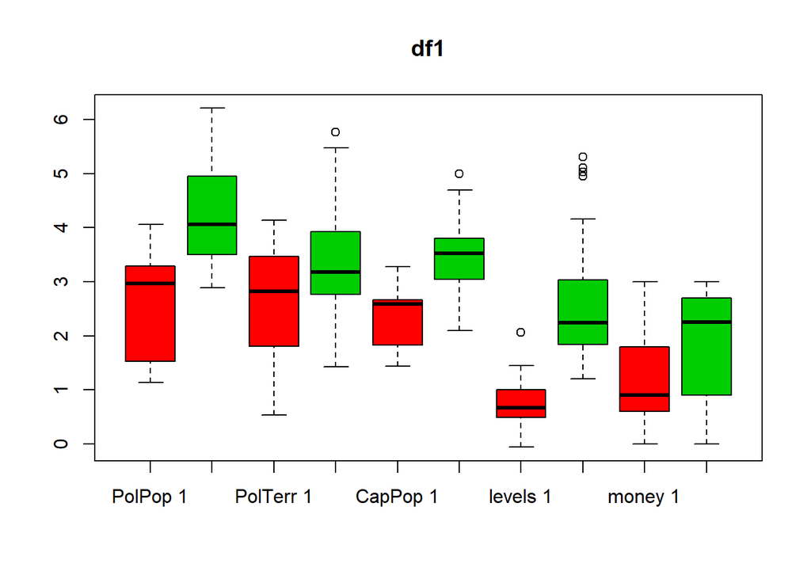

```r
df1.petit = subset(df1,select = c(government,infrastr,writing,texts))
df1.grand = subset(df1,select = c(PolPop,PolTerr,CapPop,levels,money))
df1.grand.all = list()

for(nom in names(df1.grand))
{
  for(i in 1:k)
  {
      df1.grand.all[[paste(nom,i)]] <- df1.grand[kmeans.result$cluster==i,nom]
  }
}
boxplot(df1.grand.all,col = rep(c(2:(k+1)),length(df1.grand)), main = "df1")
```

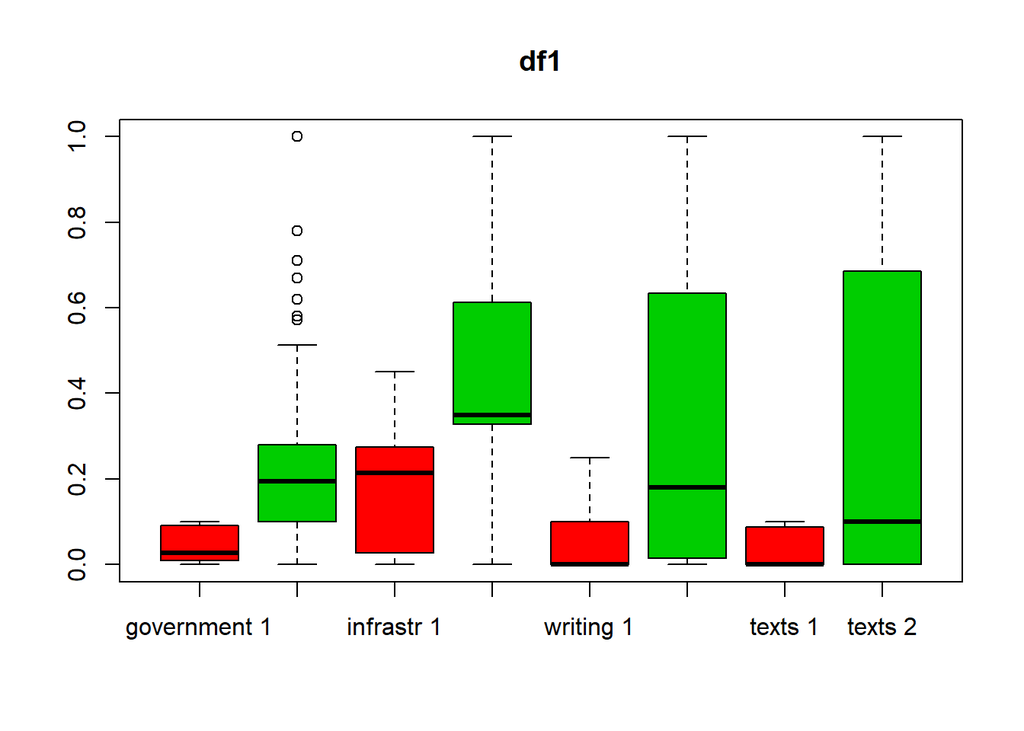

```r
df1.petit.all = list()

for(nom in names(df1.petit))
{
  for(i in 1:k)
  {
      df1.petit.all[[paste(nom,i)]] <- df1.petit[kmeans.result$cluster==i,nom]
  }
}
boxplot(df1.petit.all,col = rep(c(2:(k+1)),length(df1.petit)), main = "df1")
```

```r
# data.petit.all <- list(data.petit.1$government,data.petit.2$government))
# head(data.petit.all)
```

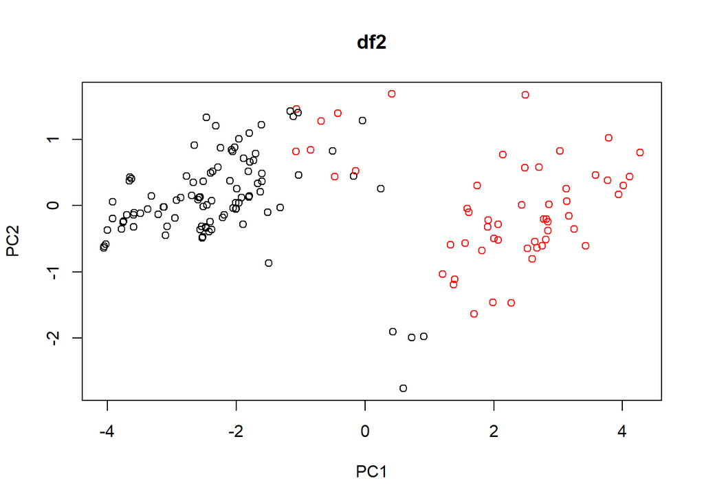

```r
k = 2
kmeans.result = kmeans(df2,2)
plot(C2[,1:2],type="p",xlab='PC1',ylab='PC2',col = kmeans.result$cluster, main = "df2") #affiche kmeans en acp
```

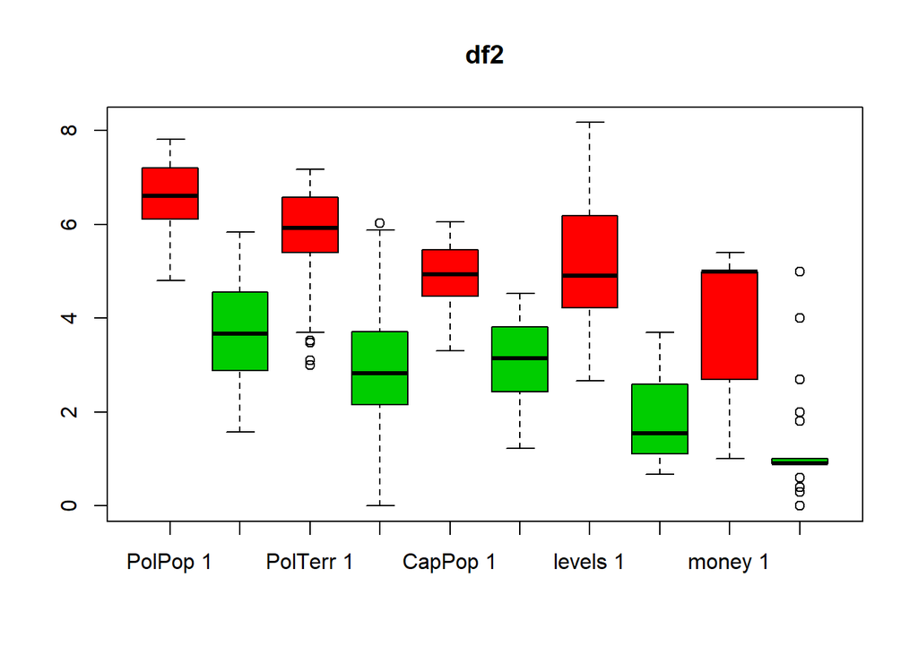

```r
df2.petit = subset(df2,select = c(government,infrastr,writing,texts))
df2.grand = subset(df2,select = c(PolPop,PolTerr,CapPop,levels,money))
df2.grand.all = list()

for(nom in names(df2.grand))
{
  for(i in 1:k)
  {
      df2.grand.all[[paste(nom,i)]] <- df2.grand[kmeans.result$cluster==i,nom]
  }
}
boxplot(df2.grand.all,col = rep(c(2:(k+1)),length(df2.grand)), main = "df2")
```

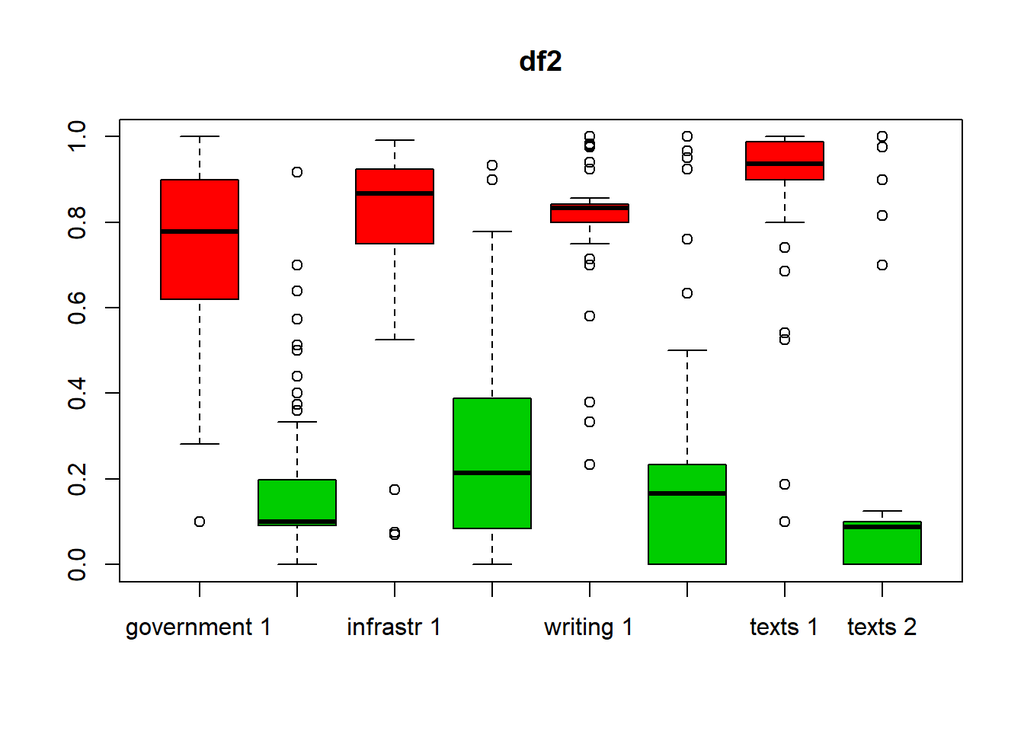

```r
df2.petit.all = list()

for(nom in names(df2.petit))
{
  for(i in 1:k)
  {
      df2.petit.all[[paste(nom,i)]] <- df2.petit[kmeans.result$cluster==i,nom]
  }
}
boxplot(df2.petit.all,col = rep(c(2:(k+1)),length(df2.petit)), main = "df2")
```

```r
# data.petit.all <- list(data.petit.1$government,data.petit.2$government))
# head(data.petit.all)
```

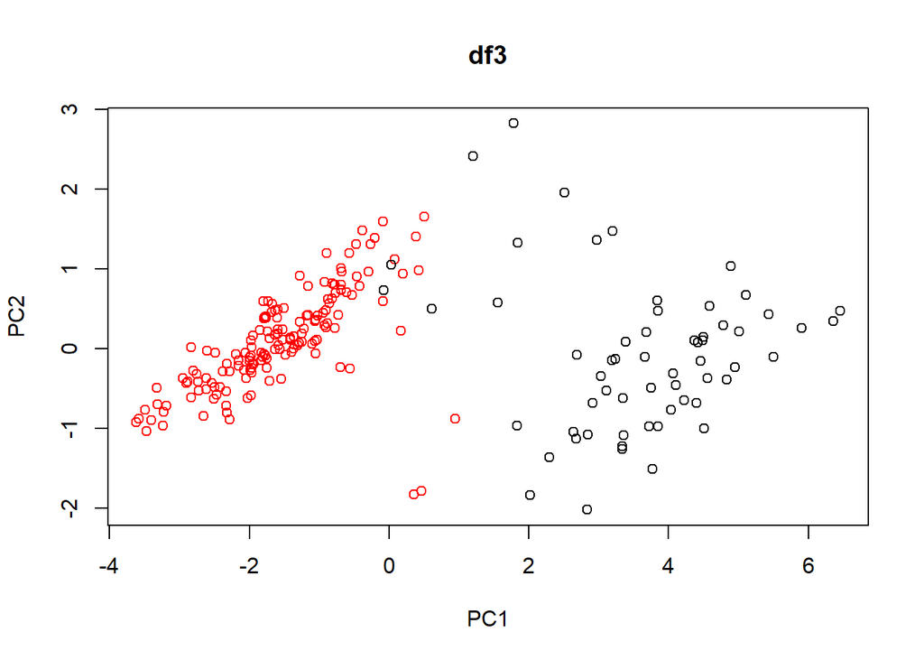

```r
k = 2
kmeans.result = kmeans(df3,2)
plot(C3[,1:2],type="p",xlab='PC1',ylab='PC2',col = kmeans.result$cluster, main = "df3") #affiche kmeans en acp
```

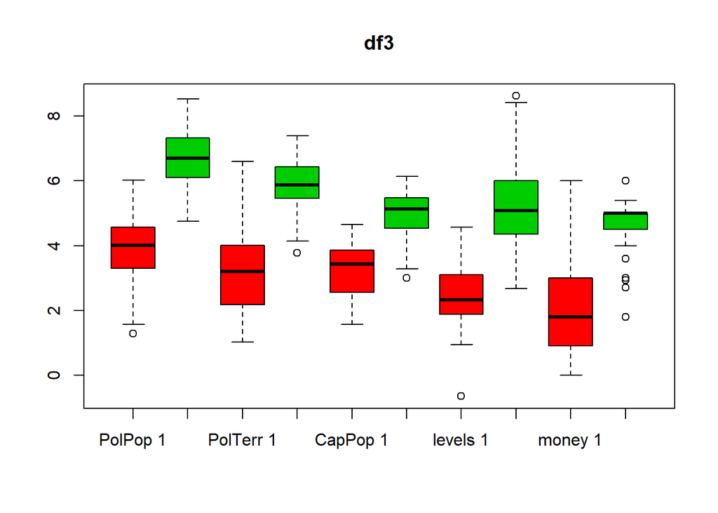

```r
df3.petit = subset(df3,select = c(government,infrastr,writing,texts))
df3.grand = subset(df3,select = c(PolPop,PolTerr,CapPop,levels,money))
df3.grand.all = list()

for(nom in names(df3.grand))
{
  for(i in 1:k)
  {
      df3.grand.all[[paste(nom,i)]] <- df3.grand[kmeans.result$cluster==i,nom]
  }
}
boxplot(df3.grand.all,col = rep(c(2:(k+1)),length(df3.grand)), main = "df3")
```

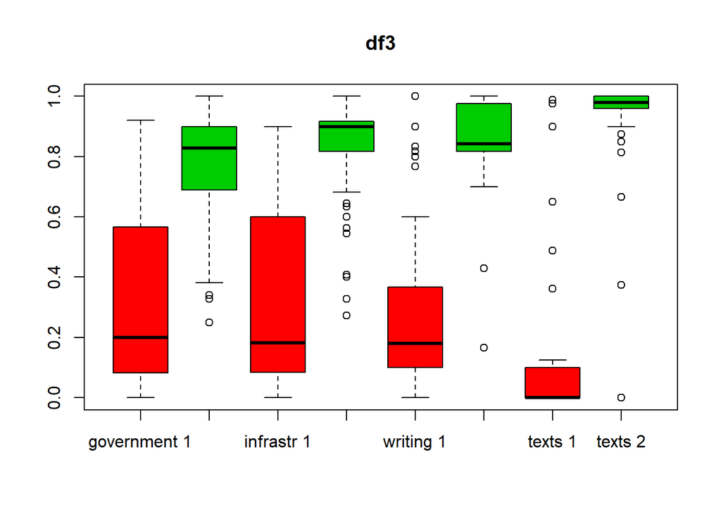

```r
df3.petit.all = list()

for(nom in names(df3.petit))
{
  for(i in 1:k)
  {
      df3.petit.all[[paste(nom,i)]] <- df3.petit[kmeans.result$cluster==i,nom]
  }
}
boxplot(df3.petit.all,col = rep(c(2:(k+1)),length(df3.petit)), main = "df3")
```

```r
# data.petit.all <- list(data.petit.1$government,data.petit.2$government))
# head(data.petit.all)
```